# VU [183.653](https://tiss.tuwien.ac.at/course/courseDetails.xhtml?courseNr=183653) Methodical, industrial Software-Engineering using the Haskell **fun**ctional programming language

2013-03-18

# Haskell Implementations

- We will use the **Glasgow Haskell Compiler** (GHC).
- There are a couple of Haskell implementations, but GHC is the go-to implementation for stability and support for language extensions.
- Most of the Haskell research and development is centered around GHC.
- The current stable version of GHC is version 7.6.2 (released in January 2013); The next major stable version 7.8.1 of GHC will most likely be released this Summer.
- Stable major GHC versions are released once a year currently (usually around ICFP).
- Information about other Haskell implementations can be found at http://www.haskell.org/haskellwiki/Implementations

# Haskell Platform

- GHC-based common platform for using and developing applications in Haskell.
- Attempt to reproduce Python's "Batteries Included" principle.
- Currently available for Linux 32/64-bit, OSX 32/64-bit, and Windows 32-bit.
- Current release 2012.4 still based on old GHC 7.4.2; Release 2013.2 (due in May 2013) will be GHC 7.6.2 based.
- Some Linux distributions as Debian/Ubuntu have it in their repositories: `apt-get install haskell-platform`
- Get it at http://www.haskell.org/platform

# Editing Haskell Source

- You should use whatever text editor/IDE you are familiar with. Here are some popular choices (in alphabetic order):
  - Eclipse (+ EclipseFP plugin)
  - Emacs (+ haskell-mode)
  - Leksah
  - Vim (+ haskell-mode-vim)
  - ...
- Highly recommended features: Syntax-highlighting, indentation/alignment support
- Nice-to-have features: Integration with GHCi REPL, tab-completion, documentation lookup
- The majority of Haskell developers seem to prefer a programmer-friendly text-editor such as Emacs or Vim.

# Compile & Run Haskell Programs

- `ghc --make -O1 -Wall program.hs` will compile a Haskell program into an executable `program` with additional compile-time warnings and a basic optimization level.
- `runghc program.hs` will run the Haskell program by interpretation.
- Or you can load it up in the GHCi REPL:

  ```
  $ ghci ./program.hs
  GHCi, version 7.6.2: http://www.haskell.org/ghc/  :? for help
  Loading package ghc-prim ... linking ... done.
  Loading package integer-gmp ... linking ... done.
  Loading package base ... linking ... done.
  [1 of 1] Compiling Main             ( program.hs, interpreted )
  Ok, modules loaded: Main.
  *Main> :main
  Hello World!
  *Main> _
  ```

  Note: if you don't see the `interpreted` keyword for a module, you might have a compiled module lying around.

# Haskell Language Report

- Haskell is a language with **non-strict semantics** (however, **lazy evaluation** is a popular implementation method to meet the required semantics).
- Stated as part of the primary goals in the Preface:  
  *"It should be suitable for teaching, research, and applications, including **building large systems**."*
- Defines the basic Haskell **language**, the Haskell standard **library**, and the Foreign Function Interace (**FFI**).
- Pragma directive for language **extensions**
- Current version at http://www.haskell.org/onlinereport/haskell2010

# Haskell 2010: What's new since Haskell 98?

Integrates a couple of widely used language extensions such as:

- The Foreign Function Interface (FFI) addendum has been merged
- Hierarchical module names (e.g. `Data.List`)
- Pattern guards
- `LANGUAGE` Pragma
- Empty datatypes (aka *uninhabited* types, e.g. `data Void`)

# Haskell 2010: What's new since Haskell 98?

...but also support for some misfeatures is removed/deprecated:

- The (*n* + *k*) pattern syntax

  ```haskell
  factorial     0 = 1
  factorial (n+1) = (n+1) * factorial n
  ```

- Datatype context, e.g.:

  ```haskell
  data Eq a => Set a = Set [a]
  ```

# Simple Functions

The following simple function already shows many language properties:

```haskell
filter :: (a -> Bool) -> [a] -> [a]
filter p []    = []
filter p (x:xs)
  | p x        = x : filter p xs
  | otherwise  = filter p xs
```

- Polymorphic type signature
- Pattern matching & guards
- Currying
- Recursion

# User-defined Fixity

- Definable by `infixl`, `infix` and `infixr` declarations
- Predefined fixities for standard operators:

  ```haskell
  infixl 9  !!  -- default fixity
  infixr 9  .
  infixr 8  ^, ^^, ⋆⋆
  infixl 7  ⋆, /, `quot`, `rem`, `div`, `mod`
  infixl 6  +, -
  infixr 5  ++, :
  infix  4  ==, /=, <, <=, >=, >, `elem`, `notElem`
  infixr 3  &&
  infixr 2  ||
  infixl 1  >>, >>=
  infixr 1  =<<
  infixr 0  $, $!, `seq`
  ```

- Function application binds stronger than level 9
- User-defined fixities can be useful in EDSL-like situations, but careless abuse can lead to confusing code easily.

# Basic Types

- Every value/expression has a type!
- Some basic types:
  - `()` - "unit" or "0-ary tuple"
  - `Bool` - boolean value
  - `Char` - Unicode code-point
  - `[Char]` - aka `String` - avoid like the plague!
  - `Int` - bounded integer
  - `Integer` - big-num integer
  - `Double` - IEEE double-precision floating-point number
  - `Int->Bool` - A function from `Int` to `Bool`

# Basic Types

- The `Bool` type definition is nothing special:

  ```haskell
  data Bool = False | True
            deriving (Eq,Ord,Read,Show,Enum,Bounded)
  ```

  But the Haskell report depends on the `Bool` type for some of its definitions (e.g. the `if/else` expression).
- Some types can't be user defined, e.g. the list type has a special syntax:

  ```haskell
  -- not valid Haskell98
  data [] a = [] | a : [a]
            deriving (Eq,Ord,Read,Show)
  infixr 5 :
  ```

- Enumeration types such as `Char` which provide literal syntax are special too:

  ```haskell
  -- pseudo code!
  data Char = '\NUL' | ... | ' ' | '!' | '"' | ... | 'A' | ...
            deriving (Eq,Ord,Read,Show,Enum,Bounded)
  ```

# Weak Head Normal Form

- Expressions are said to be in Weak Head Normal Form (WHNF) if the outermost constructor of an expression is "known".  
  In the WHNF examples below, `⊥` may represent any unevaluated sub-expression aka **thunk**, *including* bottom:

  ```haskell
  (1,True)
  True
  (⊥,⊥)
  []
  (⊥:⊥)
  [⊥,1,2,3]
  \x -> ⊥    -- the lambda-abstraction "constructor"
  filter odd -- partially applied functions
  ```

- Pattern-matching and `seq` are the primitive operations that can "force" a value into WHNF (or a divergence ⊥)

# Bottom

- In H98 every type is implicitly inhabited by the special value ⊥ ("bottom").
- `⊥ :: a` is the only value with an universal unconstrained type.
- This is different from a Null-pointer: You can't test if a value is ⊥ in H98.
- The value ⊥ represents error values which are technically not distinguishable from non-termination.
- The standard Prelude defines the following two functions for creating bottom-values on purpose:

  ```haskell
  error :: String -> a
  undefined :: a
  ```

- When a ⊥ is forced to WHNF during execution the Haskell program terminates!

# Partial vs. Total Functions

- A **total function** may only return ⊥ if its input arguments contain ⊥.
- A **partial function** is a function that is not a total function.
- Some partial functions from the standard Prelude:

  ```haskell
  head :: [a] -> a
  maximum :: Ord a => [a] -> a
  (!!) :: [a] -> Int -> a
  read :: Read a => String -> a
  ```

- Non-exhaustive pattern matches are primitive source of partial functions, e.g.:

  ```haskell
  head (x:_) = x
  ```

- **Partial functions should be avoided whenever possible** as they are hidden mines waiting to blow up. However, we can't avoid partial functions completely, as this would restrict us to programs which are provably terminating.

# `seq`

- The special `seq` function is defined as

  ```haskell
  seq :: a -> b -> b
  ⊥ `seq` b = ⊥
  a `seq` b = b
  ```

  In practice, this causes `a` to be reduced to WHNF when `seq a b` is reduced to WHNF as a "side-effect".
- Note: `seq` breaks η-conversion, i.e. it makes `\x → ⊥ x` distinguishable from `⊥`
- Prelude also defines `$!` (c.f. `$`) operator for simulating strict function application:

  ```haskell
  ($!) :: (a -> b) -> a -> b
  f $! x  = x `seq` f x
  infixr 0 $!
  ```

# User Definable Types

- Haskell 98 provides 3 ways to introduce new types:
  - `type` - for defining auch type synonyms
  - `data` - for defining fully fledged algebraic types, i.e. multiple constructors and fields
  - `newtype` - combination of `type` and `data`; similiar to single-constructor/field `data` type but with less overhead
- Two different namespaces: Type constructors & Data constructors
- `data` as well as `newtype` allow for **labelled fields**:

  ```haskell
  data C = F { f1,f2 :: Int, f3 :: Bool }
  ```

  - Labelled fields implicitly define field accessors such as `f1 :: C -> Int`
  - Labelled fields provide special record update syntax:

    ```haskell
    foo = F 1 2 3
    doo = F { f2 == 33 }  -- some fields are undefined!
    bar = foo { f2 = 22 }
    ```

    **Warning**: Labelled fields can lead to partial functions

# Strict Data Fields

- Haskell 98 has support for making data fields *strict* by prepending `!` to fields, e.g.

  ```haskell
  Data C = F Int !Int Bool
  ```

- The strictness annotation has only an effect for value construction.
- The semantics for the value constructors are roughly translated into

  ```haskell
  F a b c = b `seq` F' a b c -- pseudo-code!
  ```

  where `F'` represents the corresponding primitive value constructor (without strictness).

# Kinds

- Kinds are to type expressions what types are to value expressions.
- Haskell 98 defines the following kinds:
  - `*` - the primitive kind of nullary type constructors, e.g. `Int` or `Maybe Char`
  - `* → *` - the kind of unsaturaed type constructors which need exactly one type, e.g. `Maybe` or `[]`
  - *k1* `→` *k2* - generally, if *k1* and *k2* are kinds, then *k1* `→` *k2* is the kind of types that take a type of kind *k1* and yield a type of kind *k2*
- Language extensions exist in GHC to allow to specify "kind signatures", introduce new primitive kinds beyond `*`, or support kind polymorphism.

# Parametric Polymorphism

- Which valid implementations are there for the following type-signature?

  ```haskell
  foo :: (a,b) -> a
  foo = ...
  ```

- Unconstrained type-variables provide the least possible information about a type, because type-variables are universally quantified over all concrete types.
- Type-classes provide **ad-hoc polymorphism** and more information about what can be done with an instance of now constrained type-variable.

# Type-classes

- Type-classes define **type-indexed dictionaries** of associated functions/values, thus no value is required for dispatch:

  ```haskell
  foo :: Int
  foo = maxBound
  ```

- Each additional typeclass constraint gets translated into an implicit parameter for the typeclass dictionary, e.g. the following (notice the bug, btw?):

  ```haskell
  eqList :: (Eq a) => [a] -> [a] -> Bool
  eqList x y = and $ zipWith (==) x y
  ```

  gets translated into something like

  ```haskell
  data EqDict a = EqDict { isEq, isNEq :: a->a->Bool }

  eqList :: EqDict a -> [a] -> [a] -> Bool
  eqList eqDict x y = and $ zipWith (isEq eqDict) x y
  ```

  Often the compiler is able to inline and optimize the type-class dictionary away.
- Haskell 98 supports automatic derivation of instances for `Eq`, `Ord`, `Enum`, `Bounded`, `Show`, and `Read`.

# Typeclass Example: `NFData`

- `seq` only provides WHNF reduction, i.e. "shallow" NF
- Let's define an operation `deepseq` in the style of `seq` but which reduces its first argument to NF instead of just WHNF.

  ```haskell
  deepseq :: a -> b -> b
  ```

  Alas, there's no way to make it work in H98 with that type-signature.
- Typeclasses to the rescue:

  ```haskell
  class NFData a where
      deepseq :: a -> b -> b
  ```

  Note: This diverges from the actual definition of the real `NFData` class

# Typeclass Example: `NFData` *(cont.)*

- Instances for primitive types can be defined in terms of `seq`:

  ```haskell
  instance NFData Int      where deepseq = seq
  instance NFData Integer  where deepseq = seq
  instance NFData Char     where deepseq = seq
  instance NFData Bool     where deepseq = seq
  instance NFData Double   where deepseq = seq
  instance NFData ()       where deepseq = seq
  ...
  ```

- And now for the instances where NF differs from WHNF:

  ```haskell
  instance NFData a => NFData (Maybe a) where
      deepseq Nothing  y = y
      deepseq (Just x) y = x `deepseq` y

  instance (NFData a, NFData b) => NFData (a,b) where
      deepseq (x1,x2) y = x1 `deepseq` x2 `deepseq` y

  instance NFData a => NFData [a] where
      deepseq []     y = y
      deepseq (x:xs) y = x `deepseq` xs `deepseq` y
  ...
  ```

# Module System

- Haskell provides a module system that allows to group definitions and declarations into **distinct namespaces**.
- It is possible to restrict the visible names by explicit **export lists**, allowing e.g. for ADTs by exporting only the type but not the primitive value constructors. Notable exception: Typeclass instances can't be hidden (unless the class is hidden as well).
- Other modules can be made visible in the current module scope by **import** statements, which support qualified/unqalified imports, and/or explicitly naming the names to be imported.
- Modules can **re-export** other modules to help flatten a huge module hierarchy and reduce the number of needed import statements for users of the library.
- A Haskell file missing the `module` header gets prepended implicitly:

  ```haskell
  module Main(main) where
  ```

# Module System *(cont.)*

Simple example showing some features:

```haskell
Module Foo.Bar (module Foo.Bar.Doo, head, f1, f2,
                T1, T2(C1), T3(..)) where

import Foo.Bar.Doo            -- re-exported as-is
import Foo.Bar.Zoo (f1)       -- f1 is re-exported
import qualified Data.Bar.Zoo as Zoo
import Prelude hiding (head)

data T1 = HiddenConstr        -- only T1 is exported
data T2 = C1 | C2             -- only T2 and C1 is exported
data T3 = D1 | D2 | D3        -- complete type exported

f2 x = Zoo.f2 $! x

head :: [a] -> Maybe a
head []     = Nothing
head (x:_)  = x
```

# Impure Computations

- So far, we've only talked about **pure** code.
- "If a tree falls in a forest and no one is around to hear it, does it make a sound?"
- We need observable effects, such as interacting with the world.
- We need an observer: The `main :: IO ()` function of the `Main` module provide the entry point.
- Smallest valid trivial H98 program (but no effects):

  ```haskell
  main = return ()
  ```

  And here's the canonical hello-world program in H98:

  ```haskell
  main = putStrLn "Hello World!"
  ```

# `do` Notation

- The `do` notation is just syntax sugar that gets translated to applications of the typeclass methods `>>`, `>>=`, `fail`, and some use of lambda abstractions. For instance,

  ```haskell
  main = do putStr "What is your first name? "
            first <- getLine
            putStr "And your last name? "
            last <- getLine
            let full = first++" "++last
            putStrLn ("Pleased to meet you, "++full++"!")
  ```

  can be translated into

  ```haskell
  main = putStr "What is your first name? "  >>
         getLine                             >>= \first ->
         putStr "And your last name? "       >>
         getLine                             >>= \last  ->
         let full = first++" "++last in
         putStrLn ("Pleased to meet you, "++full++"!")
  ```

- Btw, `x >> y` is just a shortcut for `x >>= \_ -> y`

# The `IO` type

- Notice that we didn't use the intimidating M-word yet.
- From a practical point of view, there's nothing special about the `Monad` typeclass (of which `IO` happens to be an instance), except for Haskell providing the `do` syntax sugar.
- The really magic thing is the `IO` type (with kind `* → *`), which happens to be an instance of the `Monad` typeclass.
- The `IO a` type *can* be imagined as representing:

  ```haskell
  type IO a = World -> (a, World)
  ```

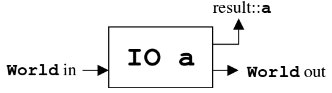

- That strange `World` represents the state of the entire world!

# The `IO` type *(cont.)*

- Consider the two basic I/O functions:

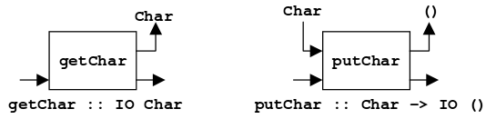

  ```haskell
  getChar :: IO Char
  putChar :: Char -> IO ()
  ```

- To combine them, we need a sequencing **combinator**

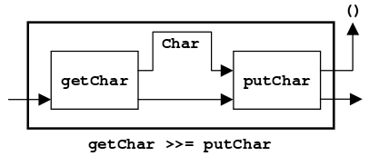

  ```haskell
  (>>=) :: IO a -> (a -> IO b) -> IO b
  ```

# The `IO` type *(cont.)*

- Figuratively speaking, `main` is provided with an initial `World`-state and then the runtime-system forces the evaluation of the final `World`-state.
- A value of type `IO a` is an action that when *performed* or run yields some result (of type `a`) and maybe some side-effect. Forcing a value of type `IO a` to WHNF (e.g. via `seq`) just acts at the glueing-level (i.e. forcing the `>>=` composition to get evaluated).
- This a convenient abstraction to integrate side-effects into a purely functional language such as Haskell with lazy evaluation.
- Important property: Impure computations such as I/O have to be declared explicitly at the type-level.

# Haskell Kernel Sub-Language

Into which language subset can Haskell 98 be desugared?

- function application: `f x`
- lambda abstraction: `\x → e`
- case expression: `case x of { p1 → e1; ... }`
- simple algebraic type declarations: `data T = C1 | C2 T2`
- value bindings: `main = ...`

# Haskell kernel Sub-Language *(cont.)*

The Haskell Language Report refers to a

- "small subset of Haskell that we call the **Haskell kernel**" which is
- "not formally specified" but
- "essentially a slightly sugared variant of the **lambda calculus** with a straightforward denotational semantics" by which
- "translation of each syntactic structure into the kernel is given"

# Haskell kernel Sub-Language *(cont.)*

For instance, the `if/else` expression

```haskell
if e1 then e2 else e3
```

is simplified into...

# Haskell kernel Sub-Language *(cont.)*

For instance, the `if/else` expression

```haskell
if e1 then e2 else e3
```

is simplified into

```haskell
case e1 of { True -> e2 ; False -> e3 }
```

# Haskell kernel Sub-Language *(cont.)*

An infix function definition such as

```haskell
True || _     = True
_    || True  = True
_    || _     = False
```

can be reduced to

```haskell
(||) = \x1 x2 -> case (x1,x2) of { (True,_) -> True
                                 ; (_,True) -> True
                                 ; (_,_   ) -> False
                                 }
```

Later on, we'll discuss a similiar minimal language called "GHC Core".